# Significant Earthquakes, 1965-2016. EDA

### Observaciones

El dataframe cuenta con 23412 observaciones, que van desde el 01/02/1965 al 12/30/2016

```python
data_quakes.head()
```

|  | Date | Time | Latitude | Longitude | Type | Depth | Depth Error | Depth Seismic Stations | Magnitude | Magnitude Type | ... | Magnitude Seismic Stations | Azimuthal Gap | Horizontal Distance | Horizontal Error | Root Mean Square | ID | Source | Location Source | Magnitude Source | Status |
| --- | --- | --- | --- | --- | --- | --- | --- | --- | --- | --- | --- | --- | --- | --- | --- | --- | --- | --- | --- | --- | --- |
| 0 | 01/02/1965 | 13:44:18 | 19.246 | 145.616 | Earthquake | 131.6 | NaN | NaN | 6.0 | MW | ... | NaN | NaN | NaN | NaN | NaN | ISCGEM860706 | ISCGEM | ISCGEM | ISCGEM | Automatic |
| 1 | 01/04/1965 | 11:29:49 | 1.863 | 127.352 | Earthquake | 80.0 | NaN | NaN | 5.8 | MW | ... | NaN | NaN | NaN | NaN | NaN | ISCGEM860737 | ISCGEM | ISCGEM | ISCGEM | Automatic |
| 2 | 01/05/1965 | 18:05:58 | -20.579 | -173.972 | Earthquake | 20.0 | NaN | NaN | 6.2 | MW | ... | NaN | NaN | NaN | NaN | NaN | ISCGEM860762 | ISCGEM | ISCGEM | ISCGEM | Automatic |
| 3 | 01/08/1965 | 18:49:43 | -59.076 | -23.557 | Earthquake | 15.0 | NaN | NaN | 5.8 | MW | ... | NaN | NaN | NaN | NaN | NaN | ISCGEM860856 | ISCGEM | ISCGEM | ISCGEM | Automatic |
| 4 | 01/09/1965 | 13:32:50 | 11.938 | 126.427 | Earthquake | 15.0 | NaN | NaN | 5.8 | MW | ... | NaN | NaN | NaN | NaN | NaN | ISCGEM860890 | ISCGEM | ISCGEM | ISCGEM | Automatic |

5 rows × 21 columns

```python
data_quakes.tail()
```

|  | Date | Time | Latitude | Longitude | Type | Depth | Depth Error | Depth Seismic Stations | Magnitude | Magnitude Type | ... | Magnitude Seismic Stations | Azimuthal Gap | Horizontal Distance | Horizontal Error | Root Mean Square | ID | Source | Location Source | Magnitude Source | Status |
| --- | --- | --- | --- | --- | --- | --- | --- | --- | --- | --- | --- | --- | --- | --- | --- | --- | --- | --- | --- | --- | --- |
| 23407 | 12/28/2016 | 08:22:12 | 38.3917 | -118.8941 | Earthquake | 12.30 | 1.2 | 40.0 | 5.6 | ML | ... | 18.0 | 42.47 | 0.120 | NaN | 0.1898 | NN00570710 | NN | NN | NN | Reviewed |
| 23408 | 12/28/2016 | 09:13:47 | 38.3777 | -118.8957 | Earthquake | 8.80 | 2.0 | 33.0 | 5.5 | ML | ... | 18.0 | 48.58 | 0.129 | NaN | 0.2187 | NN00570744 | NN | NN | NN | Reviewed |
| 23409 | 12/28/2016 | 12:38:51 | 36.9179 | 140.4262 | Earthquake | 10.00 | 1.8 | NaN | 5.9 | MWW | ... | NaN | 91.00 | 0.992 | 4.8 | 1.5200 | US10007NAF | US | US | US | Reviewed |
| 23410 | 12/29/2016 | 22:30:19 | -9.0283 | 118.6639 | Earthquake | 79.00 | 1.8 | NaN | 6.3 | MWW | ... | NaN | 26.00 | 3.553 | 6.0 | 1.4300 | US10007NL0 | US | US | US | Reviewed |
| 23411 | 12/30/2016 | 20:08:28 | 37.3973 | 141.4103 | Earthquake | 11.94 | 2.2 | NaN | 5.5 | MB | ... | 428.0 | 97.00 | 0.681 | 4.5 | 0.9100 | US10007NTD | US | US | US | Reviewed |

5 rows × 21 columns

```python
data_quakes.describe()
```

|  | Latitude | Longitude | Depth | Depth Error | Depth Seismic Stations | Magnitude | Magnitude Error | Magnitude Seismic Stations | Azimuthal Gap | Horizontal Distance | Horizontal Error | Root Mean Square |
| --- | --- | --- | --- | --- | --- | --- | --- | --- | --- | --- | --- | --- |
| count | 23412.000000 | 23412.000000 | 23412.000000 | 4461.000000 | 7097.000000 | 23412.000000 | 327.000000 | 2564.000000 | 7299.000000 | 1604.000000 | 1156.000000 | 17352.000000 |
| mean | 1.679033 | 39.639961 | 70.767911 | 4.993115 | 275.364098 | 5.882531 | 0.071820 | 48.944618 | 44.163532 | 3.992660 | 7.662759 | 1.022784 |
| std | 30.113183 | 125.511959 | 122.651898 | 4.875184 | 162.141631 | 0.423066 | 0.051466 | 62.943106 | 32.141486 | 5.377262 | 10.430396 | 0.188545 |
| min | -77.080000 | -179.997000 | -1.100000 | 0.000000 | 0.000000 | 5.500000 | 0.000000 | 0.000000 | 0.000000 | 0.004505 | 0.085000 | 0.000000 |
| 25% | -18.653000 | -76.349750 | 14.522500 | 1.800000 | 146.000000 | 5.600000 | 0.046000 | 10.000000 | 24.100000 | 0.968750 | 5.300000 | 0.900000 |
| 50% | -3.568500 | 103.982000 | 33.000000 | 3.500000 | 255.000000 | 5.700000 | 0.059000 | 28.000000 | 36.000000 | 2.319500 | 6.700000 | 1.000000 |
| 75% | 26.190750 | 145.026250 | 54.000000 | 6.300000 | 384.000000 | 6.000000 | 0.075500 | 66.000000 | 54.000000 | 4.724500 | 8.100000 | 1.130000 |
| max | 86.005000 | 179.998000 | 700.000000 | 91.295000 | 934.000000 | 9.100000 | 0.410000 | 821.000000 | 360.000000 | 37.874000 | 99.000000 | 3.440000 |

### Descripción de los datos

- Depth:
  - La media de profundidad de los eventos es de 70 km.
  - Hay una alta desviación típica de los datos, siendo de 122.65.
  - La profundidad máxima ha sido de 700 km.
- Depth Error:
  - Ha habido 4461 errores en la estimación de los eventos.
  - La media de los errores de estimación es de 5 km.
- Magnitude:
  - La media en la magnitud de los eventos ha sido de 5.88.
  - Baja desviación típica de los datos, de 0.4.
  - La magnitud máxima reportada ha sido de 9.1.
- Magnitude Error:
  - Se han reportado 327 errores en la estimación de los eventos. Valor bastante más inferior al error de la profundidad.
  - La media de los errores de estimación es de 0.07.
  - El valor máximo reportado de error en la estiación es de 0.4.

```python
# Se eliminan las columnas de ID y todas las que informan sobre la fuente que reportó el evento ya que
# no interesa la información que otorgan.

data_quakes.drop(['ID', 'Location Source', 'Magnitude Source'], axis = 1, inplace = True)
```

```python
data_quakes.head(3)
```

|  | Date | Time | Latitude | Longitude | Type | Depth | Depth Error | Depth Seismic Stations | Magnitude | Magnitude Type | Magnitude Error | Magnitude Seismic Stations | Azimuthal Gap | Horizontal Distance | Horizontal Error | Root Mean Square | Source | Status |
| --- | --- | --- | --- | --- | --- | --- | --- | --- | --- | --- | --- | --- | --- | --- | --- | --- | --- | --- |
| 0 | 01/02/1965 | 13:44:18 | 19.246 | 145.616 | Earthquake | 131.6 | NaN | NaN | 6.0 | MW | NaN | NaN | NaN | NaN | NaN | NaN | ISCGEM | Automatic |
| 1 | 01/04/1965 | 11:29:49 | 1.863 | 127.352 | Earthquake | 80.0 | NaN | NaN | 5.8 | MW | NaN | NaN | NaN | NaN | NaN | NaN | ISCGEM | Automatic |
| 2 | 01/05/1965 | 18:05:58 | -20.579 | -173.972 | Earthquake | 20.0 | NaN | NaN | 6.2 | MW | NaN | NaN | NaN | NaN | NaN | NaN | ISCGEM | Automatic |

### Errors

Análisis de errores en el dataframe

- Número de NaN por variable
- Sustitución o eliminación de NaN

```python
data_quakes.isnull().sum()
```

```
Date                              0
Time                              0
Latitude                          0
Longitude                         0
Type                              0
Depth                             0
Depth Error                   18951
Depth Seismic Stations        16315
Magnitude                         0
Magnitude Type                    3
Magnitude Error               23085
Magnitude Seismic Stations    20848
Azimuthal Gap                 16113
Horizontal Distance           21808
Horizontal Error              22256
Root Mean Square               6060
Source                            0
Status                            0
dtype: int64
```

#### Número de NaN por variable

Como se explica en el apartado de las variables, los valores NaN pueden estar condicionados a que no se ha reportado ninguna información debido a carencia de ella. Esto es porque no hay error en la estimacion de los eventos. Como se observa, las variables con mayor número de valores NaN son los que estiman algún tipo de error. Para estas variables se sustituiran los NaN por **0**.

Para las variables *Magnitude Seismic Stations* y *Depth Seismic Stations* hay un numero considerable de errores. Se procederá a eliminar esta variable ya que no otorga información significante para analizar.

Para el resto de variables, sustituir los NaN por el valor 0 podría condicionar los análisis estadísticos y eliminar las columnas nos haría perder información interesante, por lo que los dejaremos como **NaN**.

```python
data_quakes['Depth Error'] = data_quakes['Depth Error'].replace(np.nan, 0)
```

```python
data_quakes['Magnitude Error'] = data_quakes['Magnitude Error'].replace(np.nan, 0)
```

```python
data_quakes['Horizontal Error'] = data_quakes['Horizontal Error'].replace(np.nan, 0)
```

```python
data_quakes.drop(['Magnitude Seismic Stations', 'Depth Seismic Stations'], axis = 1, inplace = True)
```

```python
data_quakes.head(3)
```

|  | Date | Time | Latitude | Longitude | Type | Depth | Depth Error | Magnitude | Magnitude Type | Magnitude Error | Azimuthal Gap | Horizontal Distance | Horizontal Error | Root Mean Square | Source | Status |
| --- | --- | --- | --- | --- | --- | --- | --- | --- | --- | --- | --- | --- | --- | --- | --- | --- |
| 0 | 01/02/1965 | 13:44:18 | 19.246 | 145.616 | Earthquake | 131.6 | 0.0 | 6.0 | MW | 0.0 | NaN | NaN | 0.0 | NaN | ISCGEM | Automatic |
| 1 | 01/04/1965 | 11:29:49 | 1.863 | 127.352 | Earthquake | 80.0 | 0.0 | 5.8 | MW | 0.0 | NaN | NaN | 0.0 | NaN | ISCGEM | Automatic |
| 2 | 01/05/1965 | 18:05:58 | -20.579 | -173.972 | Earthquake | 20.0 | 0.0 | 6.2 | MW | 0.0 | NaN | NaN | 0.0 | NaN | ISCGEM | Automatic |

Nueva variable Year a partir de los datos de Date.

Encontramos ciertas filas que tienen mal introducido los datos de Date, lo que dificulta la posterior visualización de esta variable.

```python
r1 = map(lambda x : x.split('/')[-1], data_quakes.Date)
data_quakes['Year'] = list(r1)
data_quakes.head(3)
```

|  | Date | Time | Latitude | Longitude | Type | Depth | Depth Error | Magnitude | Magnitude Type | Magnitude Error | Azimuthal Gap | Horizontal Distance | Horizontal Error | Root Mean Square | Source | Status | Year |
| --- | --- | --- | --- | --- | --- | --- | --- | --- | --- | --- | --- | --- | --- | --- | --- | --- | --- |
| 0 | 01/02/1965 | 13:44:18 | 19.246 | 145.616 | Earthquake | 131.6 | 0.0 | 6.0 | MW | 0.0 | NaN | NaN | 0.0 | NaN | ISCGEM | Automatic | 1965 |
| 1 | 01/04/1965 | 11:29:49 | 1.863 | 127.352 | Earthquake | 80.0 | 0.0 | 5.8 | MW | 0.0 | NaN | NaN | 0.0 | NaN | ISCGEM | Automatic | 1965 |
| 2 | 01/05/1965 | 18:05:58 | -20.579 | -173.972 | Earthquake | 20.0 | 0.0 | 6.2 | MW | 0.0 | NaN | NaN | 0.0 | NaN | ISCGEM | Automatic | 1965 |

#### Después de limpiar la base de datos, guardar la base de datos limpia

https://towardsdatascience.com/exploratory-data-analysis-tutorial-in-python-15602b417445 (por el final)

```python
data_quakes.to_csv('../data/clean_earthquakes.csv')
```

Diferentes fuentes que han reportado temblores.

```python
data_quakes['Source'].value_counts()
```

```
US           20630
ISCGEM        2460
ISCGEMSUP      120
CI              61
GCMT            55
NC              51
AK              12
OFFICIAL         8
UW               6
NN               4
ATLAS            3
PR               1
SE               1
Name: Source, dtype: int64
```

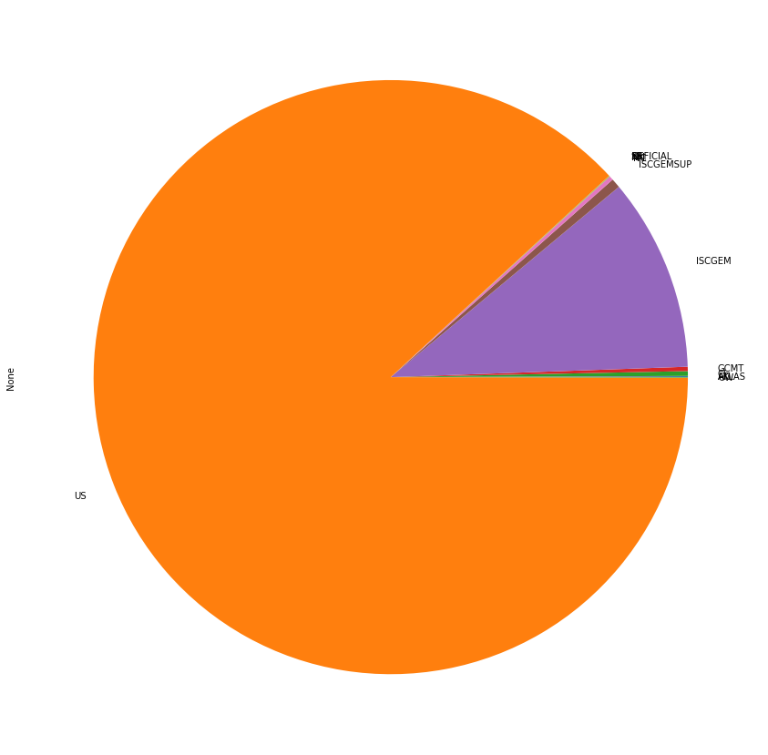

```python
quakes_source = data_quakes.groupby(by = 'Source')

fig = plt.subplot()

quakes_source.size().plot.pie(figsize = (20, 15))
plt.show()
```

Gráficamente, se puede observar (dificilmente) cuantos eventos ha reportado cada fuente.

```python
data_quakes['Type'].value_counts()
```

```
Earthquake           23232
Nuclear Explosion      175
Explosion                4
Rock Burst               1
Name: Type, dtype: int64
```

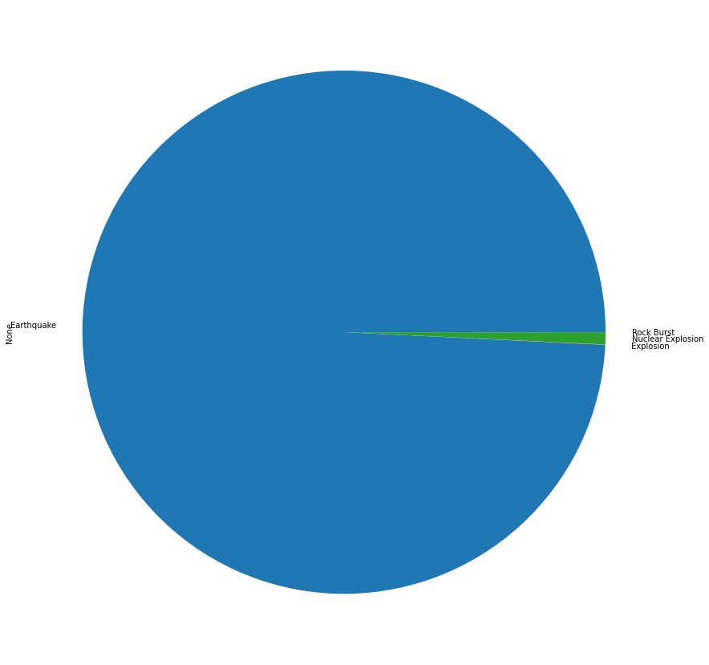

```python
quakes_type = data_quakes.groupby(by = 'Type')

fig = plt.subplot()

quakes_type.size().plot.pie(figsize = (20, 15))
plt.show()
```

Número de diferentes seismos reportados. La mayoría se trata de terremotos pero también se pueden observar 175 terremotos provocados por explosiones nucleares

### Histograma de las diferentes variables

```
array([[<AxesSubplot:title={'center':'Latitude'}>,
        <AxesSubplot:title={'center':'Longitude'}>,
        <AxesSubplot:title={'center':'Depth'}>],
       [<AxesSubplot:title={'center':'Depth Error'}>,
        <AxesSubplot:title={'center':'Magnitude'}>,
        <AxesSubplot:title={'center':'Magnitude Error'}>],
       [<AxesSubplot:title={'center':'Azimuthal Gap'}>,
        <AxesSubplot:title={'center':'Horizontal Distance'}>,
        <AxesSubplot:title={'center':'Horizontal Error'}>],
       [<AxesSubplot:title={'center':'Root Mean Square'}>,
        <AxesSubplot:>, <AxesSubplot:>]], dtype=object)
```

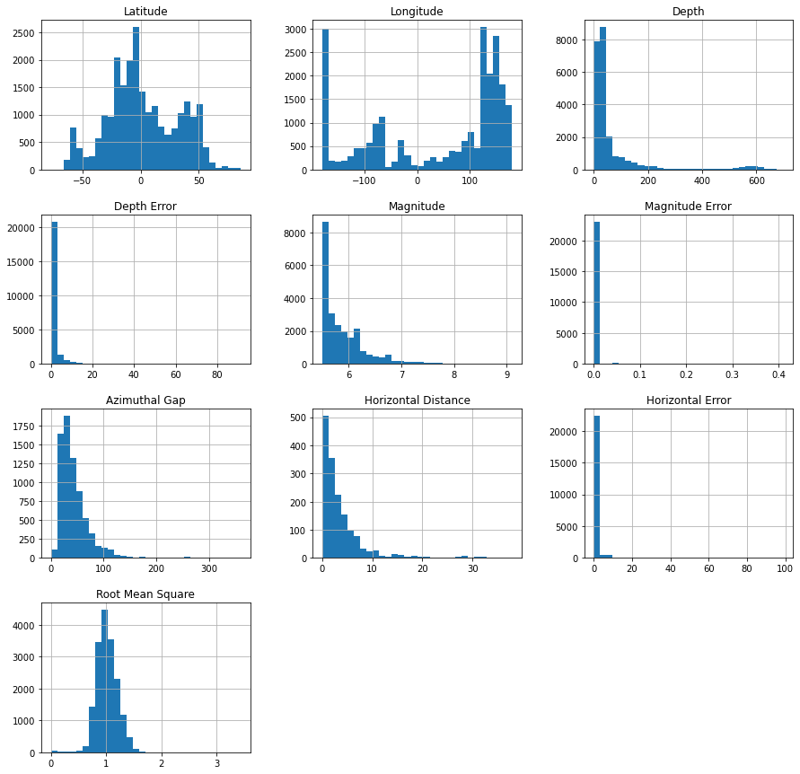

```python
data_quakes.hist(figsize = (15,15), bins = 30)
```

### Análisis del número de terremotos por año

```python
year_quakes = data_quakes.groupby(by = 'Year').count()
```

```python
#Agrupar por año a partir de la columna creada de Year.
year_quakes = data_quakes.groupby(['Year']).size().reset_index(name = 'Total terremotos')
year_quakes.head()
```

|  | Year | Total terremotos |
| --- | --- | --- |
| 0 | 1965 | 339 |
| 1 | 1966 | 234 |
| 2 | 1967 | 255 |
| 3 | 1968 | 305 |
| 4 | 1969 | 323 |

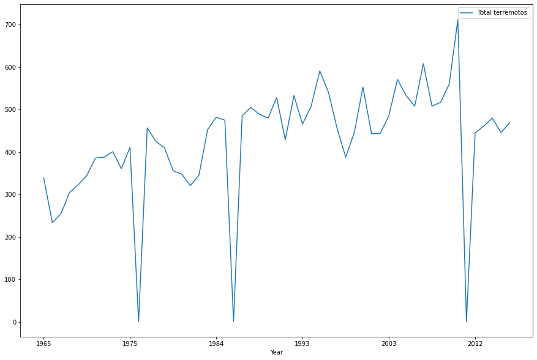

```python
year_quakes.plot(figsize = (15, 10), x = 'Year')
```

Se puede observar un aumento a lo largo de los años de los terremotos reportados. Esto puede ser debido a dos situaciones: la mejora en las tecnologías, que han permitido detectar más terremotos o debido a que la actividad sismica del planeta está aumentando.

## CORRELATION PLOT

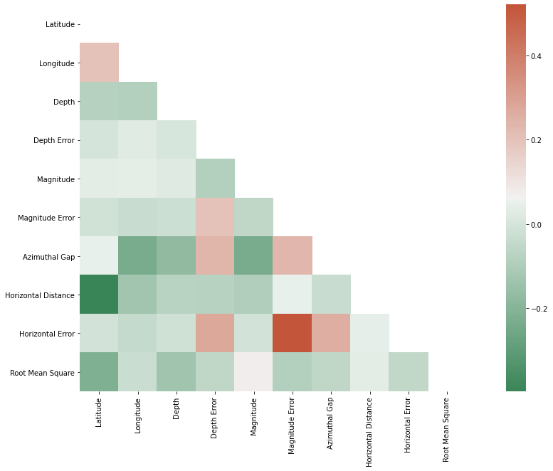

```python
corr = data_quakes.corr()

mask = np.triu(np.ones_like(corr, dtype = bool))

cmap = sns.diverging_palette(500, 20, as_cmap=True)

fig, ax = plt.subplots(figsize = (20, 10))

sns.heatmap(corr, mask = mask, cmap = cmap, square = True, ax = ax)
```

#### Análisis correlaciones

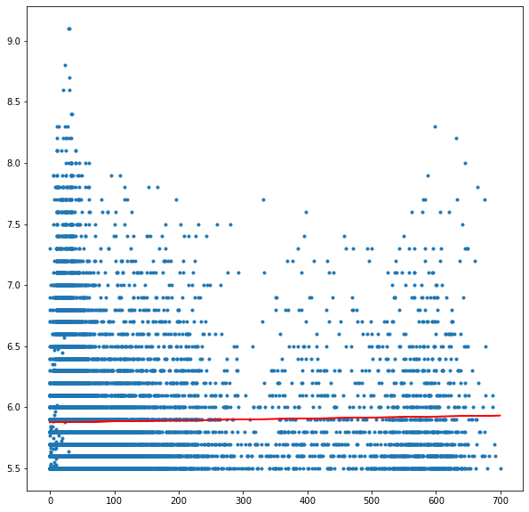

```python
#Relación entre depth y magnitude
depth = data_quakes.iloc[:, 5].values.reshape(-1, 1)
mag = data_quakes.iloc[:, 7].values.reshape(-1, 1)

linear_regressor = sk.LinearRegression()
linear_regressor.fit(depth, mag)
mag_pred = linear_regressor.predict(depth)

fig = plt.figure(figsize = (10,10))

plt.scatter(depth, mag, marker = '.')
ax1.set_title('Relación entre la profundidad y la magnitud del seismo')
ax1.set_xlabel('Depth')
ax1.set_ylabel('Magnitude')

plt.plot(depth, mag_pred, color ='red')
```

Entre las variables de profundidad y magnitud de los eventos, no se encuentra relación alguna.

```python
data_quakes['Depth Error'] = data_quakes['Depth Error'].replace(np.nan, 0)
data_quakes['Magnitude Error'] = data_quakes['Magnitude Error'].replace(np.nan, 0)
```

```python
quakes1 = data_quakes.dropna()

quakes1.isna().sum()
```

```
Date                   0
Time                   0
Latitude               0
Longitude              0
Type                   0
Depth                  0
Depth Error            0
Magnitude              0
Magnitude Type         0
Magnitude Error        0
Azimuthal Gap          0
Horizontal Distance    0
Horizontal Error       0
Root Mean Square       0
Source                 0
Status                 0
Year                   0
dtype: int64
```

```python
quakes1.head()
```

|  | Date | Time | Latitude | Longitude | Type | Depth | Depth Error | Magnitude | Magnitude Type | Magnitude Error | Azimuthal Gap | Horizontal Distance | Horizontal Error | Root Mean Square | Source | Status | Year |
| --- | --- | --- | --- | --- | --- | --- | --- | --- | --- | --- | --- | --- | --- | --- | --- | --- | --- |
| 565 | 12/20/1966 | 15:30:01 | 37.302167 | -116.408333 | Nuclear Explosion | 1.2 | 31.61 | 5.62 | ML | 0.245 | 261.0 | 1.4760 | 99.00 | 0.86 | CI | Reviewed | 1966 |
| 890 | 04/09/1968 | 02:29:00 | 33.179833 | -116.103000 | Earthquake | 10.0 | 31.61 | 6.60 | MW | 0.000 | 128.0 | 0.6012 | 0.88 | 0.33 | CI | Reviewed | 1968 |
| 897 | 04/26/1968 | 15:00:02 | 37.295333 | -116.455667 | Nuclear Explosion | 1.2 | 31.61 | 5.63 | ML | 0.125 | 261.0 | 1.4380 | 99.00 | 1.03 | CI | Reviewed | 1968 |
| 1129 | 12/19/1968 | 16:30:01 | 37.231500 | -116.473667 | Nuclear Explosion | 1.4 | 31.61 | 5.52 | ML | 0.219 | 257.0 | 1.4150 | 99.00 | 1.36 | CI | Reviewed | 1968 |
| 1380 | 09/16/1969 | 14:30:01 | 37.314167 | -116.460667 | Nuclear Explosion | 1.2 | 31.61 | 5.82 | ML | 0.187 | 268.0 | 1.4370 | 99.00 | 0.33 | CI | Reviewed | 1969 |

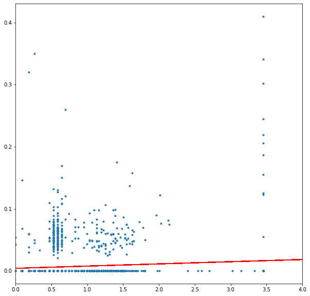

```python
depth_err = quakes1.iloc[:, 6].values.reshape(-1, 1)
mag_err = quakes1.iloc[:, 9].values.reshape(-1, 1)

linear_regressor = sk.LinearRegression()
linear_regressor.fit(depth_err, mag_err)
mager_pred = linear_regressor.predict(depth_err)

fig = plt.figure(figsize = (10,10))

plt.scatter(np.log(depth_err), mag_err, marker = '.')
ax1.set_title('Relación entre el error en profundidad y el error en magnitud del seismo')
ax1.set_xlabel('Depth Error')
ax1.set_ylabel('Magnitude Error')
plt.xlim([0, 4])
plt.plot(depth_err, mager_pred, color ='red')
```

Entre las variables de Depth Error y Magnitude Error, la pendiente de la líene de regresión es ligeramente superior a 0.

## Referencias

- Earthquake documentation: https://earthquake.usgs.gov/data/comcat/index.php#1
- Matplotlib visualizations: https://www.machinelearningplus.com/plots/top-50-matplotlib-visualizations-the-master-plots-python/
- https://matplotlib.org/gallery/index.html
- Seaborn documentation: https://seaborn.pydata.org/
- Matplotlib functions: https://www.geeksforgeeks.org/